In this Notebook, the aim is to illustrate, with four simple graphs, the macroeconomic issues of Argentina and how they affect employment in terms of price (wages) and quantity.

# Libraries

```python
import numpy as np
import pandas as pd
from datetime import datetime

import matplotlib.dates as dates
import matplotlib.pyplot as plt
from prettytable import PrettyTable

import warnings
warnings.filterwarnings("ignore")
```

# Data

For the purpose of conducting the relevant analyses, the data was manually downloaded and converted into TXT format. This was done because some of the paths cannot be accessed directly from Python. Therefore, if you wish to do the same through different methods, at the bottom of the following links, you will find the hyperlinks contained within each of them, from which the data can be downloaded. Links: - https://data.worldbank.org/indicator/NY.GDP.DEFL.KD.ZG?locations=AR (1) - https://data.worldbank.org/indicator/NY.GDP.MKTP.KD.ZG?locations=AR (2) - https://www.argentina.gob.ar/economia/politicaeconomica/macroeconomica/gastopublicoconsolidado (3) - https://www.trabajo.gov.ar/downloads/estadisticas/trabajoregistrado/trabajoregistrado_2203_estadisticas.xlsx - https://datos.gob.ar/ar/dataset/sspm-asalariados-registrados-sector-privado-por-provincia/archivo/sspm_154.1 (4) - https://www.indec.gob.ar/indec/web/Nivel4-Tema-4-31-61 (5)(6) - https://www.indec.gob.ar/indec/web/Nivel4-Tema-3-9-48 (7) 1. Data: Inflation since 1960. Format: CSV. 2. Data: GDP since 1960. Format: CSV. 3. Data: Consolidated public spending since 1980. Format: XLS. 4. DOWNLOAD (green background with white capital letters). Format: XLSX. 5. Wage Index. Index numbers and percentage variations compared to the previous period and accumulated, by sector. October 2015-April 2022. 6. Wage Index, values as of the last day of each month, from October 2001 onwards (linking the base series from Q4 2001=100 with the base series from April 2012=100). 7. Monthly economic activity indicator, base 2004. Index numbers (base 2004=100) and percentage variations. Years 2004-2022.

### Jobs per Province since 2009

```python
n_jobs_per_province = pd.read_csv("empleoProv.txt", sep='\t') # employment since 2009
print("raw data".title())
display(n_jobs_per_province.head())

n_jobs_per_province['total'] = n_jobs_per_province[n_jobs_per_province.select_dtypes("number").columns].sum(axis = 1)
n_jobs_per_province['indice_tiempo'] = pd.to_datetime(n_jobs_per_province['indice_tiempo'])
n_jobs_per_province.set_index('indice_tiempo', inplace = True)

print("\nprocessed data".title())
display(n_jobs_per_province.head())
```

```
Raw Data
```

|  | indice_tiempo | asalariados_priv_buenos_aires | asalariados_priv_caba | asalariados_priv_catamarca | asalariados_priv_chaco | asalariados_priv_chubut | asalariados_priv_cordoba | asalariados_priv_corrientes | asalariados_priv_entre_rios | asalariados_priv_formosa | ... | asalariados_priv_neuquen | asalariados_priv_rio_negro | asalariados_priv_salta | asalariados_priv_san_juan | asalariados_priv_san_luis | asalariados_priv_santa_cruz | asalariados_priv_santa_fe | asalariados_priv_santiago_estero | asalariados_priv_tierra_fuego | asalariados_priv_tucuman |
| --- | --- | --- | --- | --- | --- | --- | --- | --- | --- | --- | --- | --- | --- | --- | --- | --- | --- | --- | --- | --- | --- |
| 0 | 2009-01-01 | 1787.640 | 1469.941 | 29.789 | 59.917 | 93.274 | 457.589 | 63.403 | 118.240 | 20.594 | ... | 92.927 | 109.325 | 100.327 | 73.954 | 52.385 | 54.735 | 459.325 | 41.929 | 27.006 | 129.765 |
| 1 | 2009-02-01 | 1769.223 | 1467.029 | 30.504 | 60.212 | 92.852 | 456.084 | 63.791 | 118.017 | 20.837 | ... | 93.316 | 111.229 | 100.914 | 74.532 | 51.639 | 55.166 | 453.637 | 41.987 | 26.465 | 130.383 |
| 2 | 2009-03-01 | 1745.913 | 1466.167 | 31.819 | 61.331 | 93.235 | 454.039 | 64.836 | 119.666 | 20.947 | ... | 91.581 | 107.136 | 100.215 | 76.425 | 51.528 | 54.718 | 454.632 | 42.328 | 26.185 | 137.924 |
| 3 | 2009-04-01 | 1729.917 | 1454.724 | 31.261 | 61.796 | 91.650 | 451.044 | 64.309 | 119.799 | 20.963 | ... | 87.304 | 93.602 | 97.142 | 74.261 | 51.046 | 53.979 | 452.583 | 42.547 | 25.744 | 149.951 |
| 4 | 2009-05-01 | 1723.218 | 1451.374 | 30.366 | 62.265 | 90.353 | 447.114 | 64.257 | 120.941 | 21.130 | ... | 85.173 | 88.599 | 98.239 | 72.668 | 50.783 | 52.941 | 449.091 | 42.505 | 25.276 | 155.374 |

5 rows × 25 columns

```
Processed Data
```

| indice_tiempo | asalariados_priv_buenos_aires | asalariados_priv_caba | asalariados_priv_catamarca | asalariados_priv_chaco | asalariados_priv_chubut | asalariados_priv_cordoba | asalariados_priv_corrientes | asalariados_priv_entre_rios | asalariados_priv_formosa | asalariados_priv_jujuy | ... | asalariados_priv_rio_negro | asalariados_priv_salta | asalariados_priv_san_juan | asalariados_priv_san_luis | asalariados_priv_santa_cruz | asalariados_priv_santa_fe | asalariados_priv_santiago_estero | asalariados_priv_tierra_fuego | asalariados_priv_tucuman | total |
| --- | --- | --- | --- | --- | --- | --- | --- | --- | --- | --- | --- | --- | --- | --- | --- | --- | --- | --- | --- | --- | --- |
| 2009-01-01 | 1787.640 | 1469.941 | 29.789 | 59.917 | 93.274 | 457.589 | 63.403 | 118.240 | 20.594 | 50.544 | ... | 109.325 | 100.327 | 73.954 | 52.385 | 54.735 | 459.325 | 41.929 | 27.006 | 129.765 | 5659.961 |
| 2009-02-01 | 1769.223 | 1467.029 | 30.504 | 60.212 | 92.852 | 456.084 | 63.791 | 118.017 | 20.837 | 50.327 | ... | 111.229 | 100.914 | 74.532 | 51.639 | 55.166 | 453.637 | 41.987 | 26.465 | 130.383 | 5647.381 |
| 2009-03-01 | 1745.913 | 1466.167 | 31.819 | 61.331 | 93.235 | 454.039 | 64.836 | 119.666 | 20.947 | 47.760 | ... | 107.136 | 100.215 | 76.425 | 51.528 | 54.718 | 454.632 | 42.328 | 26.185 | 137.924 | 5634.862 |
| 2009-04-01 | 1729.917 | 1454.724 | 31.261 | 61.796 | 91.650 | 451.044 | 64.309 | 119.799 | 20.963 | 45.805 | ... | 93.602 | 97.142 | 74.261 | 51.046 | 53.979 | 452.583 | 42.547 | 25.744 | 149.951 | 5576.559 |
| 2009-05-01 | 1723.218 | 1451.374 | 30.366 | 62.265 | 90.353 | 447.114 | 64.257 | 120.941 | 21.130 | 47.167 | ... | 88.599 | 98.239 | 72.668 | 50.783 | 52.941 | 449.091 | 42.505 | 25.276 | 155.374 | 5540.805 |

5 rows × 25 columns

### Jobs per Job Type since 2012

```python
n_jobs_per_type = pd.read_csv("tipoEmpleo.txt", sep='\t') # employment since 2012
print("raw data".title())
display(n_jobs_per_type.head())

def date_preprocessing(df, col):

    month_to_number = {
        'ene':1, 'feb':2, 'mar':3, 'abr':4, 'may':5, 'jun':6, 'jul':7,
        'ago':8, 'sept':9, 'oct':10, 'nov':11, 'dic':12, 'sep':9}

    df[col] = df[col].apply(lambda x: str(x).replace('*',''))

    months = df[col].str.split('-').str[0].map(month_to_number).values
    years = df[col].str.split('-').str[1]
    dates = [datetime.strptime('01-' + str(month).zfill(2) + '-' + year, '%d-%m-%y') for month, year in zip(months, years)]

    df[col] = dates

    return df

def number_preprocessing(df):
    for column in df.columns:
        if df[column].dtype == 'O':
           df[column] = df[column].str.replace(',','').astype('float')
    return df

n_jobs_per_type = date_preprocessing(df = n_jobs_per_type, col = 'Período')
n_jobs_per_type = number_preprocessing(df = n_jobs_per_type)

n_jobs_per_type.set_index('Período', inplace = True)
n_jobs_per_type.columns = [
    'Empleo privado', 'Empleo público', 'Empleo en casas particulares',
    'Autónomos', 'Monotributo', 'Monotributo Social', 'Total']
print("\nprocessed data".title())
display(n_jobs_per_type.head())
```

```
Raw Data
```

|  | Período | Empleo asalariado en el sector privado | Empleo asalariado en el sector público | Empleo en casas particulares | Trabajo Independientes Autónomos | Trbajo Independientes Monotributo | Trabajo Independientes Monotributo\r\nSocial | Total |
| --- | --- | --- | --- | --- | --- | --- | --- | --- |
| 0 | ene-12 | 6,106.0 | 2,543.7 | 389.2 | 409.9 | 1,314.7 | 167.8 | 10,931.3 |
| 1 | feb-12 | 6,103.4 | 2,598.2 | 388.8 | 408.9 | 1,314.5 | 168.9 | 10,982.7 |
| 2 | mar-12 | 6,112.4 | 2,602.1 | 386.6 | 406.5 | 1,314.6 | 170.0 | 10,992.2 |
| 3 | abr-12 | 6,055.0 | 2,605.4 | 390.0 | 407.7 | 1,317.8 | 172.5 | 10,948.4 |
| 4 | may-12 | 6,042.6 | 2,591.3 | 392.2 | 407.6 | 1,321.8 | 172.9 | 10,928.5 |

```
Processed Data
```

| Período | Empleo privado | Empleo público | Empleo en casas particulares | Autónomos | Monotributo | Monotributo Social | Total |
| --- | --- | --- | --- | --- | --- | --- | --- |
| 2012-01-01 | 6106.0 | 2543.7 | 389.2 | 409.9 | 1314.7 | 167.8 | 10931.3 |
| 2012-02-01 | 6103.4 | 2598.2 | 388.8 | 408.9 | 1314.5 | 168.9 | 10982.7 |
| 2012-03-01 | 6112.4 | 2602.1 | 386.6 | 406.5 | 1314.6 | 170.0 | 10992.2 |
| 2012-04-01 | 6055.0 | 2605.4 | 390.0 | 407.7 | 1317.8 | 172.5 | 10948.4 |
| 2012-05-01 | 6042.6 | 2591.3 | 392.2 | 407.6 | 1321.8 | 172.9 | 10928.5 |

### Monthly GDP Index since 2004

```python
monthly_gdp = pd.read_csv("EMAE.txt", sep='\t') # monthly gdp
print("raw data".title())
print(monthly_gdp.head())

monthly_gdp.index = pd.to_datetime(pd.date_range(start = '01-01-2004', end = '04-01-2022', freq = 'M').strftime('%Y-%m') + '-01')
print("\nprocessed data".title())
print(monthly_gdp.head())
```

```
Raw Data
     gdp
0   92.6
1   90.2
2  101.9
3  102.6
4  109.9

Processed Data
              gdp
2004-01-01   92.6
2004-02-01   90.2
2004-03-01  101.9
2004-04-01  102.6
2004-05-01  109.9
```

### Public Expenditure over Total GDP since 1980

```python
public_expenditure = pd.read_csv("gastoPublico.txt", sep='\t') # public expenditure
print("raw data".title())
display(public_expenditure.head())

public_expenditure.index, public_expenditure.columns = ['pubExpToGDP'], public_expenditure.columns.str.replace('*','')
public_expenditure = public_expenditure.T
print("\nprocessed data".title())
print(public_expenditure.head())
```

```
Raw Data
```

|  | 1980 | 1981 | 1982 | 1983 | 1984 | 1985 | 1986 | 1987 | 1988 | 1989 | ... | 2011 | 2012 | 2013 | 2014 | 2015 | 2016 | 2017* | 2018* | 2019* | 2020* |
| --- | --- | --- | --- | --- | --- | --- | --- | --- | --- | --- | --- | --- | --- | --- | --- | --- | --- | --- | --- | --- | --- |
| 0 | 29.037146 | 31.34255 | 28.046671 | 25.920356 | 26.58164 | 29.953943 | 32.153619 | 34.637952 | 32.174666 | 31.713259 | ... | 40.006699 | 41.279217 | 42.856229 | 44.993437 | 46.29946 | 47.308011 | 46.191927 | 43.592695 | 42.707461 | 46.836644 |

1 rows × 41 columns

```
Processed Data
      pubExpToGDP
1980    29.037146
1981    31.342550
1982    28.046671
1983    25.920356
1984    26.581640
```

### Salaries since 2001

```python
salaries_since_2015 = pd.read_csv("salDesde2015.txt", sep='\t') # salaries since 2015
salaries_until_2015 = pd.read_csv("salHasta2015.txt", sep='\t') # salaries until 2015
salaries_since_2015.index = pd.date_range(start='10-01-2015',end='04-01-2022',freq='M').strftime('%Y-%m')
salaries_until_2015.index = pd.date_range(start='10-01-2001',end='11-01-2015',freq='M').strftime('%Y-%m')

dates_sal = salaries_until_2015.index.tolist() + salaries_since_2015.index.tolist()
private_salaries = salaries_until_2015['sectorPrivado'].values.tolist() + list(
    salaries_until_2015['sectorPrivado'].values.tolist()[-1] * (1 + salaries_since_2015['sectorPrivado'].pct_change().cumsum().fillna(0)))[1:]
public_salaries = salaries_until_2015[salaries_until_2015.columns.drop('sectorPrivado')[0]].values.tolist() + list(
    salaries_until_2015[salaries_until_2015.columns.drop('sectorPrivado')[0]].values.tolist()[-1] * (
        1 + salaries_since_2015[salaries_since_2015.columns.drop('sectorPrivado')[0]].pct_change().cumsum().fillna(0)))[1:]

salaries = pd.DataFrame([dates_sal, private_salaries, public_salaries], index = ['DATE', 'PRIVATE_SECTOR_SALARY', 'PUBLIC_SECTOR_SALARY']).T.set_index('DATE')
salaries['PRIVATE_PCT_CHANGE'] = salaries['PRIVATE_SECTOR_SALARY'].pct_change().cumsum().fillna(0)
salaries['PUBLIC_PCT_CHANGE'] = salaries['PUBLIC_SECTOR_SALARY'].pct_change().cumsum().fillna(0)
print("\nprocessed data".title())
display(salaries.head())
```

```
Processed Data
```

| DATE | PRIVATE_SECTOR_SALARY | PUBLIC_SECTOR_SALARY | PRIVATE_PCT_CHANGE | PUBLIC_PCT_CHANGE |
| --- | --- | --- | --- | --- |
| 2001-10 | 14.22 | 27.99 | 0.000000 | 0.000000 |
| 2001-11 | 14.25 | 27.9 | 0.002110 | -0.003215 |
| 2001-12 | 14.23 | 27.9 | 0.000706 | -0.003215 |
| 2002-01 | 14.18 | 27.87 | -0.002808 | -0.004291 |
| 2002-02 | 14.18 | 27.87 | -0.002808 | -0.004291 |

### GDP Growth Rate since 1961

```python
gdp_growth = pd.read_csv("pbiCrec.txt", sep='\t')  # historic gdp
print("raw data".title())
display(gdp_growth.head())

gdp_growth = gdp_growth.T.rename(columns={0:'gdpGrowth'})
print("\nprocessed data".title())
display(gdp_growth.head())
```

```
Raw Data
```

|  | 1961 | 1962 | 1963 | 1964 | 1965 | 1966 | 1967 | 1968 | 1969 | 1970 | ... | 2011 | 2012 | 2013 | 2014 | 2015 | 2016 | 2017 | 2018 | 2019 | 2020 |
| --- | --- | --- | --- | --- | --- | --- | --- | --- | --- | --- | --- | --- | --- | --- | --- | --- | --- | --- | --- | --- | --- |
| 0 | 5.427843 | -0.852022 | -5.308197 | 10.130298 | 10.569433 | -0.659726 | 3.191997 | 4.822501 | 9.679526 | 3.045643 | ... | 6.003952 | -1.02642 | 2.405324 | -2.512615 | 2.73116 | -2.080328 | 2.818503 | -2.617396 | -2.025934 | -9.895269 |

1 rows × 60 columns

```
Processed Data
```

|  | gdpGrowth |
| --- | --- |
| 1961 | 5.427843 |
| 1962 | -0.852022 |
| 1963 | -5.308197 |
| 1964 | 10.130298 |
| 1965 | 10.569433 |

### Inflation Rate since 1961

```python
inflation_rate = pd.read_csv("inflacion.txt", sep='\t') # historic inflation
print("raw data".title())
display(inflation_rate.head())

inflation_rate = inflation_rate.T.rename(columns={0:'inflation'})
inflation_rate.index = inflation_rate.index.astype('int')
print("\nprocessed data".title())
display(inflation_rate.head())
```

```
Raw Data
```

|  | 1961 | 1962 | 1963 | 1964 | 1965 | 1966 | 1967 | 1968 | 1969 | 1970 | ... | 2011 | 2012 | 2013 | 2014 | 2015 | 2016 | 2017 | 2018 | 2019 | 2020 |
| --- | --- | --- | --- | --- | --- | --- | --- | --- | --- | --- | --- | --- | --- | --- | --- | --- | --- | --- | --- | --- | --- |
| 0 | 20.310698 | 28.871842 | 25.591154 | 28.774617 | 21.232935 | 25.603462 | 29.018263 | 10.275311 | 7.79583 | 6.467875 | ... | 23.703472 | 22.314881 | 23.948798 | 40.282972 | 26.579992 | 41.11938 | 26.006379 | 42.033669 | 50.921499 | 39.891217 |

1 rows × 60 columns

```
Processed Data
```

|  | inflation |
| --- | --- |
| 1961 | 20.310698 |
| 1962 | 28.871842 |
| 1963 | 25.591154 |
| 1964 | 28.774617 |
| 1965 | 21.232935 |

# Visualizations

### Economic Policies and Growth

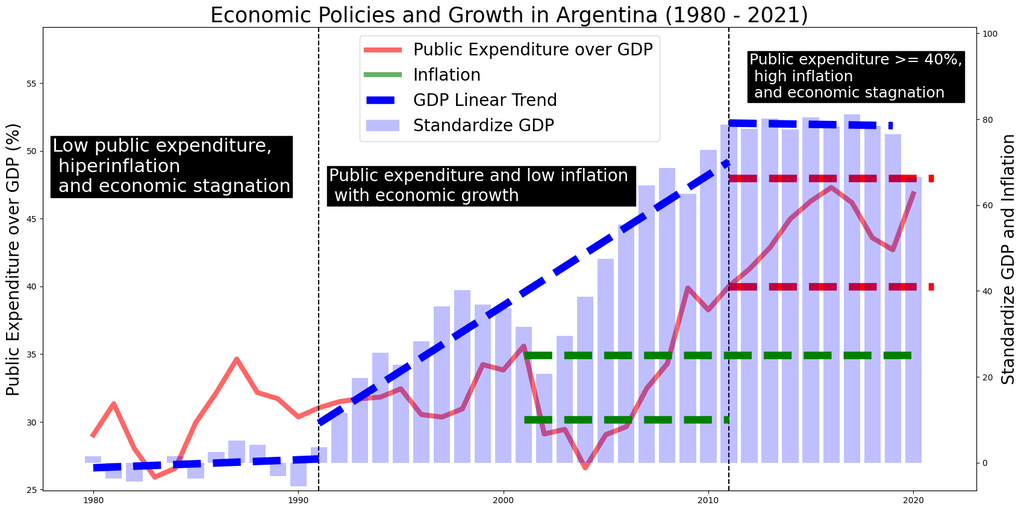

```python
public_exp_n_gdp = public_expenditure.merge(gdp_growth,left_index=True,right_index=True,how='left').merge(inflation_rate,left_index=True,right_index=True,how='left')
public_exp_n_gdp.index = public_exp_n_gdp.index.astype('int')

pub_exp_to_gdp, pub_exp_to_gdp_cum, inflation = public_exp_n_gdp.loc[:,'pubExpToGDP'], public_exp_n_gdp.loc[:,'gdpGrowth'].cumsum(), public_exp_n_gdp.loc[:,'inflation']
since_1st_period, since_2nd_period, since_3rd_period = 0, 11, 31
until_1st_period, until_2nd_period, until_3rd_period = 12, 32, 40
linewidth, linewidth_bounds, marketType = 6, 9, 'dashed'
p1 = np.poly1d(np.polyfit(x = pub_exp_to_gdp_cum.index[since_1st_period:until_1st_period].astype('float'), y = pub_exp_to_gdp_cum.iloc[since_1st_period:until_1st_period].astype('float'), deg = 1))
p2 = np.poly1d(np.polyfit(x = pub_exp_to_gdp_cum.index[since_2nd_period:until_2nd_period].astype('float'), y = pub_exp_to_gdp_cum.iloc[since_2nd_period:until_2nd_period].astype('float'), deg = 1))
p3 = np.poly1d(np.polyfit(x = pub_exp_to_gdp_cum.index[since_3rd_period:until_3rd_period].astype('float'), y = pub_exp_to_gdp_cum.iloc[since_3rd_period:until_3rd_period].astype('float'), deg = 1))

fig, ax1 = plt.subplots(figsize=(20,10))
ax2 = ax1.twinx()

ax1.plot(public_exp_n_gdp.index, pub_exp_to_gdp, color='r', linewidth = linewidth, label = 'Public Expenditure over GDP', alpha=.6)
ax2.bar(public_exp_n_gdp.index, pub_exp_to_gdp_cum, color='b', alpha = 0.25, label = 'Standardize GDP')

ax2.plot(public_exp_n_gdp.index, np.where(inflation >= 100, 100, inflation), color = 'g', linewidth = linewidth, label = 'Inflation', alpha = .6)
ax2.plot(public_exp_n_gdp.index[since_1st_period : until_1st_period], p1(public_exp_n_gdp.index[since_1st_period : until_1st_period].astype('float')), color = 'b', linewidth = linewidth_bounds, linestyle = marketType, label = 'GDP Linear Trend')
ax2.plot(public_exp_n_gdp.index[since_2nd_period : until_2nd_period], p2(public_exp_n_gdp.index[since_2nd_period : until_2nd_period].astype('float')), color = 'b', linewidth = linewidth_bounds, linestyle = marketType)
ax2.plot(public_exp_n_gdp.index[since_3rd_period : until_3rd_period], p3(public_exp_n_gdp.index[since_3rd_period : until_3rd_period].astype('float')), color = 'b', linewidth = linewidth_bounds, linestyle = marketType)

ax1.hlines(y = 40, xmin = 2011, xmax = 2021, color = 'red', linestyles = marketType, linewidth = linewidth_bounds)
ax1.hlines(y = 48, xmin = 2011, xmax = 2021, color = 'red', linestyles = marketType, linewidth = linewidth_bounds)
ax2.hlines(y = 25, xmin = 2001, xmax = 2020, color = 'green', linestyles = marketType, linewidth = linewidth_bounds)
ax2.hlines(y = 10, xmin = 2001, xmax = 2011, color = 'green', linestyles = marketType, linewidth = linewidth_bounds)
ax1.vlines(x = 1991, ymin = pub_exp_to_gdp.min() - 1, ymax = pub_exp_to_gdp.max() * 1.25, color = 'black', linestyles = marketType)
ax1.vlines(x = 2011, ymin = pub_exp_to_gdp.min() - 1, ymax = pub_exp_to_gdp.max() * 1.25, color = 'black', linestyles = marketType)

ax2.text(1978, 63, 'Low public expenditure, \n hiperinflation \n and economic stagnation', color = 'white',
         bbox = dict(facecolor = 'black', edgecolor = 'black', pad = 2.0), fontsize = 22)
ax2.text(1991.5, 61, 'Public expenditure and low inflation \n with economic growth', color = 'white',
         bbox = dict(facecolor = 'black', edgecolor = 'black', pad = 2.0), fontsize = 20)
ax2.text(2012, 85, 'Public expenditure >= 40%,\n high inflation\n and economic stagnation', color = 'white',
         bbox = dict(facecolor = 'black', edgecolor = 'black', pad = 2.0), fontsize = 18)

ax1.set_ylim(ymin = pub_exp_to_gdp.min() - 1, ymax = pub_exp_to_gdp.max() * 1.25)
ax2.set_ylim(ymin = pub_exp_to_gdp_cum.min() - 1, ymax = pub_exp_to_gdp_cum.max() * 1.25)
ax1.set_ylabel('Public Expenditure over GDP (%)', fontsize = 20)
ax2.set_ylabel('Standardize GDP and Inflation', fontsize = 20)

lines_1, labels_1 = ax1.get_legend_handles_labels()
lines_2, labels_2 = ax2.get_legend_handles_labels()
lines, labels = lines_1 + lines_2, labels_1 + labels_2
ax1.legend(lines, labels, loc = 'upper center', fontsize = 20)

plt.title('Economic Policies and Growth in Argentina (1980 - 2021)', fontsize = 25)
plt.show()
```

The first thing to clarify is that the series explaining inflation in the years where it exceeds the value of 100 is assigned this value for better and more understandable visualization in the graph. It’s also worth noting that the green and red horizontal lines aim to highlight inflation levels and public spending over GDP in specific periods. It is also important to emphasize that this graph is framed within the context that the Argentine economy, from 1880 to the present, only experienced economic stagnation (rather than growth) during the decades of 1980-1989 and 2010-2019, if we consider decades in multiples of 10. The economic policy of any government has two parts: fiscal policy and monetary policy. In the former, decisions are made about how much to spend and how much to collect in each fiscal period. In the latter, the goal is to maintain monetary stability through the institution of a monetary authority independent of the government (called the Central Bank in most countries). In fiscal matters, the less the public sector spends, the fewer resources it will need to collect, and therefore, more resources will be available for the private sector to expand its productive capacity. In monetary matters, all central banks aim to balance the supply of money with demand to avoid price level changes (inflation) that would complicate the daily operations of various agents in the domestic economy. This graph explains how, during the 1980-1989 decade, despite low public spending, extremely high inflation levels prevented the normal development of the economy, suffocating it in stagnation and ultimately leading to the greatest economic crisis in the country's history until that moment, which were the hyperinflations of 1989 and 1990, when annual inflation reached four digits in both years. After this, public spending remained low, and a monetary convertibility scheme pegged to the U.S. dollar was implemented, eliminating inflation and allowing sustained economic growth, except for 2002 when the country experienced its worst economic crisis due to rising public spending and consequent debt accumulation that could not be honored properly. However, thanks to the policies that had been implemented, a significant reduction in public spending in 2002, and rising commodity prices, which led to periods of fiscal and trade surpluses, the country recovered quickly and grew for the rest of the 2000-2009 decade, except for 2009 due to a severe drought. This growth was at the expense of a steady increase in both inflation and public spending, which, since 2012, have prevented the country from growing, and no horizon for economic recovery is currently foreseeable.

### Labour Market (Quantity)

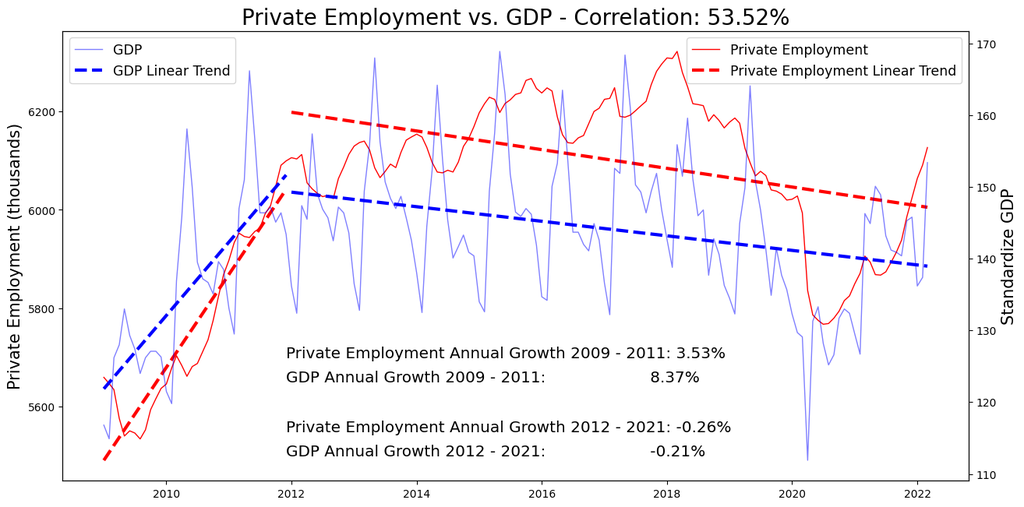

```python
gdp_n_jobs = pd.DataFrame(n_jobs_per_province['total']).merge(
    monthly_gdp,
    left_index = True,
    right_index = True,
    how = 'left')
correlation = round(np.corrcoef(
  gdp_n_jobs.iloc[:,0].astype('float'),
  gdp_n_jobs.iloc[:,1].astype('float'))[0][1] * 100, 2)

jpbs_mean_annual_growth_rate_2009_2011 = (gdp_n_jobs.loc['2011-01-01':'2011-12-01','total'].mean() / gdp_n_jobs.loc['2009-01-01':'2009-12-01','total'].mean() - 1) / (2011-2009)
jpbs_mean_annual_growth_rate_2012_2021 = (gdp_n_jobs.loc['2021-01-01':'2021-12-01','total'].mean() / gdp_n_jobs.loc['2012-01-01':'2012-12-01','total'].mean() - 1) / (2021-2011)
gpd_mean_annual_growth_rate_2009_2011 = (gdp_n_jobs.loc['2011-01-01':'2011-12-01','gdp'].mean() / gdp_n_jobs.loc['2009-01-01':'2009-12-01','gdp'].mean() - 1) / (2011-2009)
gdp_mean_annual_growth_rate_2012_2021 = (gdp_n_jobs.loc['2021-01-01':'2021-12-01','gdp'].mean() / gdp_n_jobs.loc['2012-01-01':'2012-12-01','gdp'].mean() - 1) / (2021-2011)

p1 = np.poly1d(np.polyfit(
  x = dates.date2num(gdp_n_jobs.loc['2009-01-01':'2011-12-01'].index),
  y = gdp_n_jobs.loc['2009-01-01':'2011-12-01','total'].values.astype('float'),
  deg = 1))
p2 = np.poly1d(np.polyfit(
  x = dates.date2num(gdp_n_jobs.loc['2012-01-01':'2022-03-01'].index),
  y = gdp_n_jobs.loc['2012-01-01':'2022-12-01','total'].values.astype('float'),
  deg = 1))
p3 = np.poly1d(np.polyfit(
  x = dates.date2num(gdp_n_jobs.loc['2009-01-01':'2011-12-01'].index),
  y = gdp_n_jobs.loc['2009-01-01':'2011-12-01','gdp'].values.astype('float'),
  deg = 1))
p4 = np.poly1d(np.polyfit(
  x = dates.date2num(gdp_n_jobs.loc['2012-01-01':'2022-03-01'].index),
  y = gdp_n_jobs.loc['2012-01-01':'2022-12-01','gdp'].values.astype('float'),
  deg = 1))

x_fit1 = np.linspace(
  dates.date2num(gdp_n_jobs.loc['2009-01-01':'2011-12-01'].index).min(),
  dates.date2num(gdp_n_jobs.loc['2009-01-01':'2011-12-01'].index).max())
x_fit2 = np.linspace(
  dates.date2num(gdp_n_jobs.loc['2012-01-01':'2022-03-01'].index).min(),
  dates.date2num(gdp_n_jobs.loc['2012-01-01':'2022-03-01'].index).max())

fig, ax1 = plt.subplots(figsize = (15, 7.5))
ax2 = ax1.twinx()

ax1.plot(gdp_n_jobs.index, gdp_n_jobs.iloc[:,0], c = 'r', label = 'Private Employment', linewidth = 1)
ax1.plot(dates.num2date(x_fit1), p1(x_fit1), c = 'r', label = 'Private Employment Linear Trend', linewidth = 3, linestyle = marketType)
ax1.plot(dates.num2date(x_fit2), p2(x_fit2), c = 'r', linewidth = 3, linestyle = marketType)
ax2.plot(gdp_n_jobs.index, gdp_n_jobs.iloc[:,1], c = 'b', alpha = 0.5, label = 'GDP', linewidth = 1)
ax2.plot(dates.num2date(x_fit1), p3(x_fit1), c = 'b', label = 'GDP Linear Trend', linewidth = 3, linestyle = marketType)
ax2.plot(dates.num2date(x_fit2), p4(x_fit2), c = 'b', linewidth = 3, linestyle = marketType)

ax1.text(x_fit1[-1], 5700, f'Private Employment Annual Growth 2009 - 2011: {round(jpbs_mean_annual_growth_rate_2009_2011 * 100, 2)}%', fontsize = 'x-large')
ax1.text(x_fit1[-1], 5650, f'GDP Annual Growth 2009 - 2011:                     {round(gpd_mean_annual_growth_rate_2009_2011 * 100, 2)}%', fontsize = 'x-large')
ax1.text(x_fit1[-1], 5550, f'Private Employment Annual Growth 2012 - 2021: {round(jpbs_mean_annual_growth_rate_2012_2021 * 100, 2)}%', fontsize = 'x-large')
ax1.text(x_fit1[-1], 5500, f'GDP Annual Growth 2012 - 2021:                     {round(gdp_mean_annual_growth_rate_2012_2021 * 100, 2)}%', fontsize = 'x-large')

ax1.set_ylabel('Private Employment (thousands)', fontsize = 15)
ax2.set_ylabel('Standardize GDP', fontsize = 15)
ax1.legend(loc='upper right', fontsize = 12.5)
ax2.legend(loc='upper left', fontsize = 12.5)

plt.title(f'Private Employment vs. GDP - Correlation: {correlation}%', fontsize = 20)
plt.show()
```

This graph shows the direct effect that the lack of economic growth has on employment. It is especially important to highlight the effect on private employment, as it is the sector that finances public spending and represents the largest proportion of different types of employment (see next graph). Here, we can clearly observe how during the period 2009-2011, economic growth allowed the creation of private employment, but after that, both the economy and private employment have remained stagnant. This has resulted in a deterioration in the quality of employment, as it has not kept pace with population growth. Consequently, those unable to enter or remain in the formal economy or who experience a downgrade in job quality are forced to turn to informality, state assistance, or a combination of both to meet their basic needs.

### Labour Market by Type (Quantity)

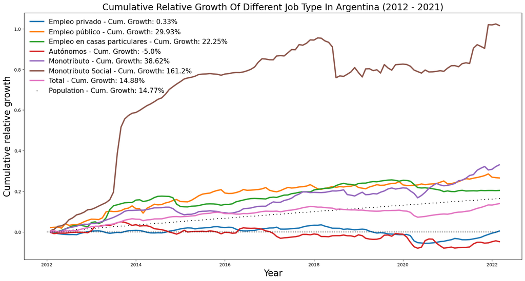

```python
population_2010, population_2022 = 40117096, 47327407
annual_growth = (population_2022 / population_2010) ** (1 / (2022 - 2010)) - 1
population_growth = round((population_2022 / (population_2010 * (1 + annual_growth) ** 2) - 1) * 100, 2)

columns = n_jobs_per_type.columns.drop('Total')
columns = pd.concat([n_jobs_per_type[col] / n_jobs_per_type['Total'] for col in columns], axis = 1, keys = columns)

firstRow, lastRow, linewidth = n_jobs_per_type.index[0], n_jobs_per_type.index[-1], 3
plt.figure(figsize=(20,10))

for col in n_jobs_per_type.columns:
  growth_rate = round((n_jobs_per_type.loc[lastRow, col] / n_jobs_per_type.loc[firstRow, col] - 1) * 100, 2)
  plt.plot(
    pd.to_datetime(n_jobs_per_type.index),
    n_jobs_per_type[col].pct_change().cumsum(),
    label = f'{col} - Cum. Growth: {growth_rate}%',
    linewidth = linewidth)
plt.scatter(pd.to_datetime(n_jobs_per_type.index), pd.Series(np.linspace(population_2010, population_2022, len(n_jobs_per_type.index))).pct_change().cumsum(), label = f'Population - Cum. Growth: {population_growth}%', color = 'black', s = 1)

plt.hlines(y = 0, xmin = n_jobs_per_type.index[0], xmax =  n_jobs_per_type.index[-1], linestyles = 'dotted', color = 'black')
plt.legend(loc = 'upper left', frameon = False, fontsize = 15)
plt.ylabel("Cumulative relative growth", fontsize = 20)
plt.xlabel('Year', fontsize = 20)
plt.title('Cumulative relative growth of different job type in Argentina (2012 - 2021)'.title(), fontsize = 20)
plt.show()
```

The first takeaway from this graph is that employment has kept pace with demographic growth, but at the expense of a reduction in its quality. In Argentina, there are various legal categories to classify the labor force. In addition to the well-known public and private employees in dependent relationships, the following categories are also included: Self-employed: independent workers with higher income capacity. "Monotributista": independent workers with lower income capacity than the self-employed. Social "Monotributista": "Monotributistas" who fall within the lowest income brackets of this category. Domestic workers: those performing household tasks. A second, more significant insight is that the growth in private employment and self-employed workers was nonexistent. Private employment generates the most value of all, and self-employed workers represent the potential future businesses of the country. At the same time, "Monotributistas," public employees, and domestic workers grew by an average of 30% during this period, while social "Monotributistas," who contribute the least value to the economy, grew by around 160%. This allows us to conclude that there was a clear decline in the quality of life for Argentinians during the period in question.

```python
x, y = PrettyTable(), PrettyTable()
x.title, y.title = 'Proportion of employees by job type in 01-2012'.title(), 'Proportion of employees by job type in 03-2022'.title()
x.field_names, y.field_names = ["Job Type", "Proportion"], ["Job Type", "Proportion"]
for i in range(columns.shape[1]):
  x.add_row([columns.columns[i],round(columns.iloc[0,i]*100,2)])
  y.add_row([columns.columns[i],round(columns.iloc[-1,i]*100,2)])
x.sortby, y.sortby = 'Proportion', 'Proportion'
x.reversesort, y.reversesort = True, True
print(x,'\n',y)
```

```
+------------------------------------------------+
| Proportion Of Employees By Job Type In 01-2012 |
+---------------------------------+--------------+
|             Job Type            |  Proportion  |
+---------------------------------+--------------+
|          Empleo privado         |    55.86     |
|          Empleo público         |    23.27     |
|           Monotributo           |    12.03     |
|            Autónomos            |     3.75     |
|   Empleo en casas particulares  |     3.56     |
|        Monotributo Social       |     1.54     |
+---------------------------------+--------------+
 +------------------------------------------------+
| Proportion Of Employees By Job Type In 03-2022 |
+---------------------------------+--------------+
|             Job Type            |  Proportion  |
+---------------------------------+--------------+
|          Empleo privado         |    48.79     |
|          Empleo público         |    26.32     |
|           Monotributo           |    14.51     |
|   Empleo en casas particulares  |     3.79     |
|        Monotributo Social       |     3.49     |
|            Autónomos            |     3.1      |
+---------------------------------+--------------+
```

### Labour Market (Price)

[figure not shown]

```python
sal_annual_growth = salaries['PRIVATE_SECTOR_SALARY'].reset_index()
sal_annual_growth['YEAR'] = pd.to_datetime(sal_annual_growth['DATE']).dt.year
years = sal_annual_growth.groupby('YEAR')['YEAR'].count()[sal_annual_growth.groupby('YEAR')['YEAR'].count() == 12].index
sal_annual_growth = sal_annual_growth[sal_annual_growth['YEAR'].isin(years)]
sal_annual_growth = sal_annual_growth.groupby('YEAR')['PRIVATE_SECTOR_SALARY'].mean().pct_change().dropna().reset_index()

real_salary = sal_annual_growth.merge(
    inflation_rate,
    left_on = 'YEAR',
    right_index = True,
    how = 'left').set_index('YEAR')
real_salary.loc['2021','inflation'] = 50.9
real_salary['inflation'] = real_salary['inflation'] / 100
real_salary = (1 + real_salary.cumsum()) * 100
real_salary['real_salary_growth'] = (1 + real_salary['PRIVATE_SECTOR_SALARY']) / (1 + real_salary['inflation']) - 1

gdp_yearly = monthly_gdp.reset_index()
gdp_yearly['YEAR'] = gdp_yearly['index'].dt.year
years = gdp_yearly.groupby('YEAR')['YEAR'].count()[gdp_yearly.groupby('YEAR')['YEAR'].count() == 12].index
gdp_yearly = gdp_yearly[gdp_yearly['YEAR'].isin(years)]
gdp_yearly = gdp_yearly.groupby('YEAR')['gdp'].mean().pct_change().dropna()

real_salary = real_salary.merge(gdp_yearly, left_index = True, right_index = True, how = 'left').dropna()

fig, ax1 = plt.subplots(figsize = (20, 10))
ax2 = ax1.twinx()

ax1.plot(real_salary.index,real_salary['real_salary_growth'], color = 'b', label = 'Real Salary Variation', linewidth = 3)
ax2.plot(real_salary.index,real_salary['gdp'], color = 'g', label = 'Standardize GDP', alpha = 0.35, linewidth = 3)
ax1.hlines(y = 0, xmin = real_salary.index[0], xmax = real_salary.index[-1], colors = 'r', linewidth = 3, linestyles = 'dashed')
ax1.set_ylabel("Salary Variation", fontsize = 20)
ax2.set_ylabel("Standardize GDP", fontsize = 20)

lines_1, labels_1 = ax1.get_legend_handles_labels()
lines_2, labels_2 = ax2.get_legend_handles_labels()
lines, labels = lines_1 + lines_2, labels_1 + labels_2
ax1.legend(lines, labels, loc = 'upper left', fontsize = 15)

plt.title("Evolution of Real Salary in Argentina (2012 - 2021)", fontsize = 25)
plt.show()
```